# final_R_part2.R

Jackie Stephens

2022-12-15

# Final Project Part 2: Data Analysis

## Data Exploration

**Numerical Exploration**

```
## here() starts at C:/Users/jbste/OneDrive/Documents/environmental_data
```

```
##   observation   genus         binomial body_mass body_length   age    sex
## 1       27526 Delomys Delomys dorsalis      50.5         259 adult female
## 2       27528 Delomys Delomys dorsalis      79.0         223 adult female
## 3       27529 Delomys Delomys dorsalis      57.0         206 adult female
## 4       27530 Delomys Delomys dorsalis      71.0         229 adult   male
## 5       27533 Delomys Delomys dorsalis      56.0         105 adult   male
## 6       27534 Delomys Delomys dorsalis      50.0         118 adult   male
##   longitude  latitude status
## 1 -48.22950 -24.20256  alive
## 2 -48.22950 -24.20256  alive
## 3 -48.22950 -24.20256  alive
## 4 -48.22950 -24.20256  alive
## 5 -50.39215 -29.40807  alive
## 6 -50.39215 -29.40807   dead
```

```
##    body_mass
##  Min.   :  5.00
##  1st Qu.: 35.00
##  Median : 43.00
##  Mean   : 44.06
##  3rd Qu.: 54.00
##  Max.   :105.00
```

```
##   body_length
##  Min.   : 49.0
##  1st Qu.:106.0
##  Median :116.0
##  Mean   :114.7
##  3rd Qu.:124.0
##  Max.   :265.0
```

```
##
##  Shapiro-Wilk normality test
##
## data:  delomys_dat$body_mass
## W = 0.99506, p-value = 4.33e-05
```

```
##
##  Shapiro-Wilk normality test
##
## data:  delomys_dat$body_length
## W = 0.87609, p-value < 2.2e-16
```

**Graphical Exploration**

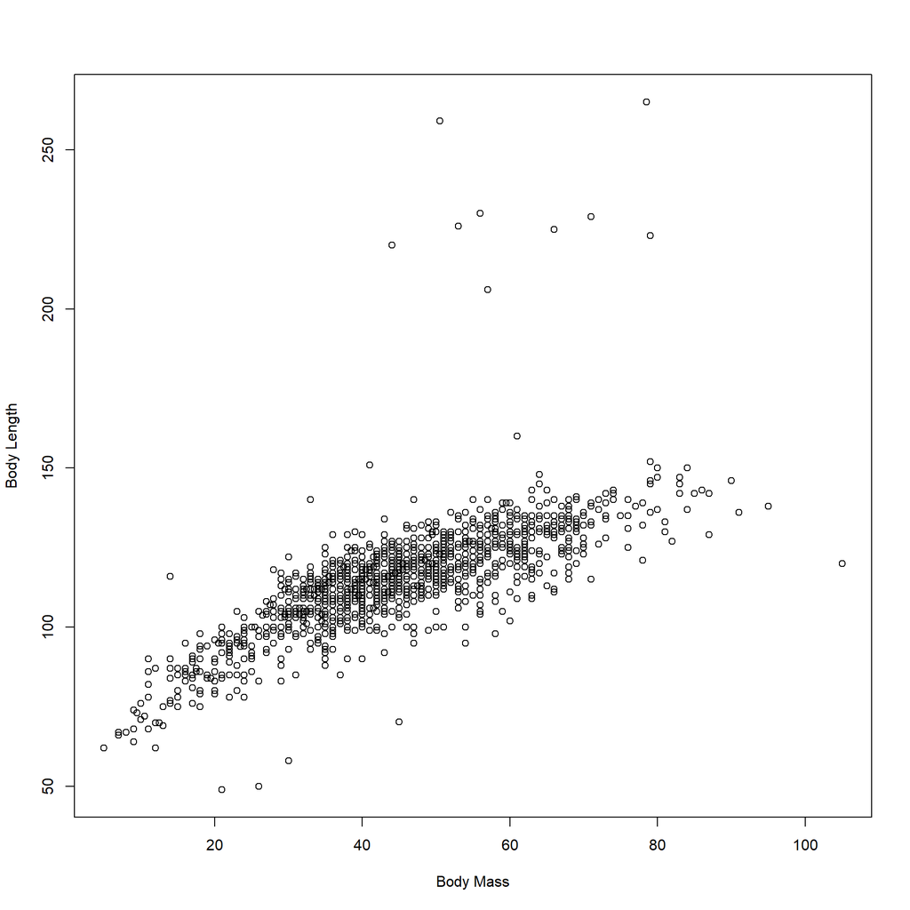

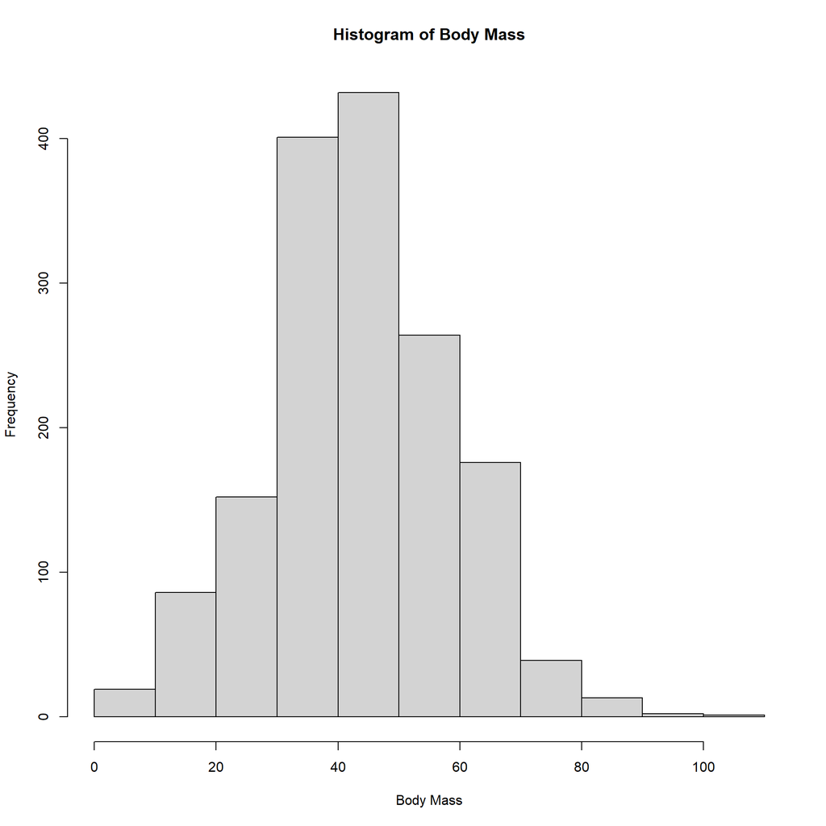

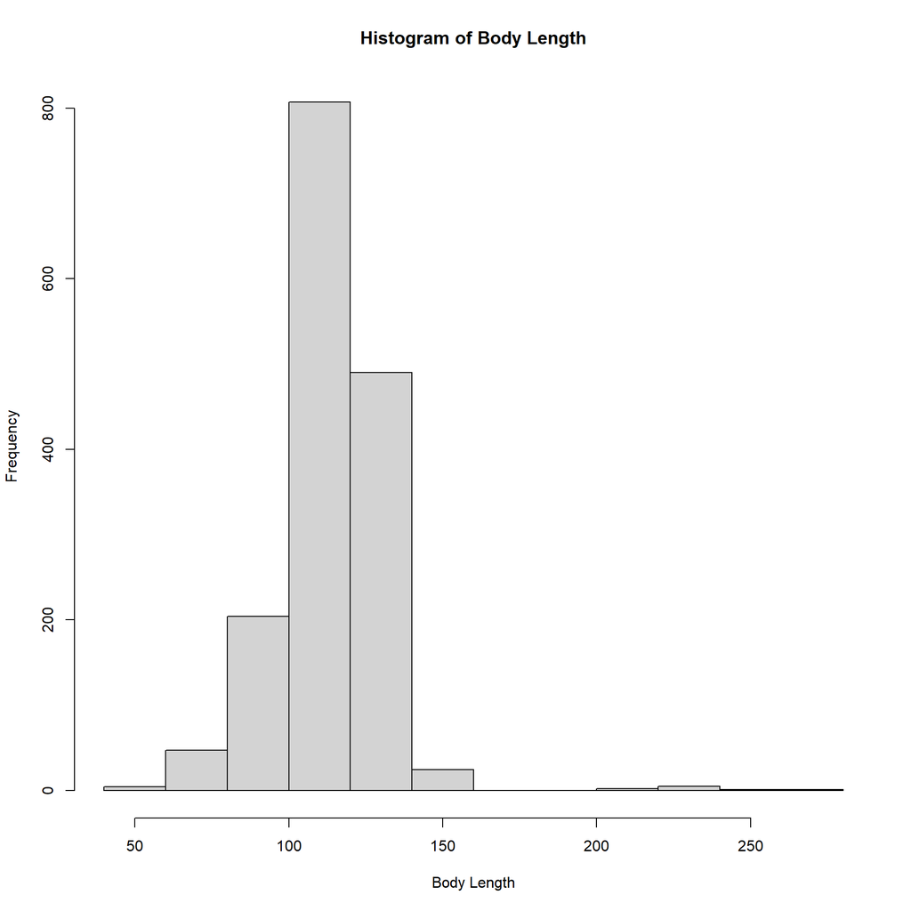

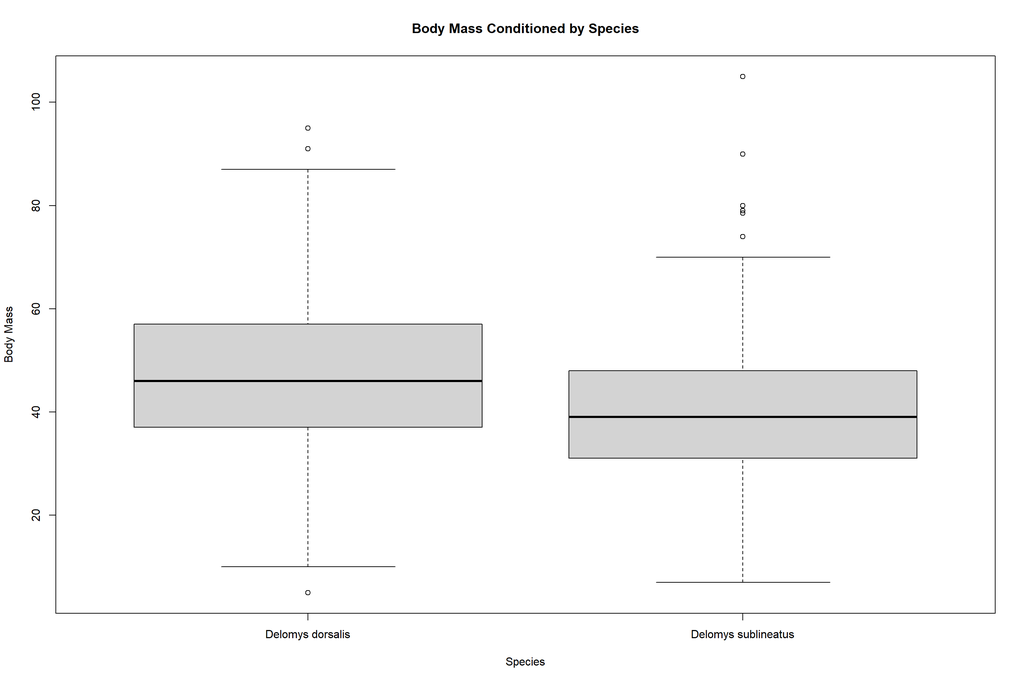

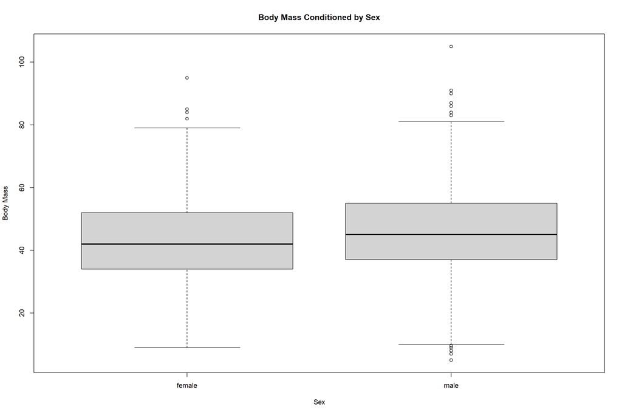

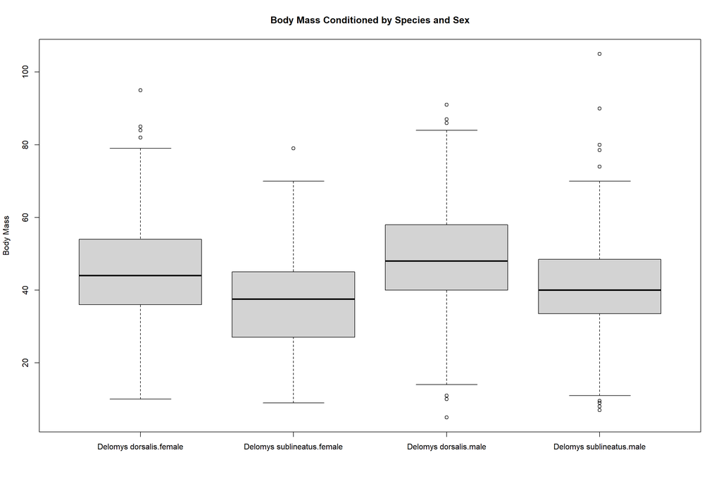

Q1: Qualitatively describe the relationship between body mass and length. Does the relationship seem linear, curved, nonexistent?

**I would describe the relationship between body mass and length as positive and linear. While the slope or rate of change/increase is not large, you can still see that as body mass increases so does body length. There are also some outliers when you get over 40 grams for body mass.**

Q2: Qualitatively describe the shapes of the histograms. Do the data appear normally distributed? Explain why or why not. Explain why we care (or not) whether the data are normally distributed.

**The histogram of body mass appears to be relatively normally distributed with a clear mean and measurements on both sides of it, (however it does looks like there is potential for skewness as there are more smaller masses than larger masses). The histogram for the body lengths does not look normally-distributed. There appears to be a disconnect in the range of body length measurements (from ~150 to 200 there are no measurements). We care about whether the data is normally distributed because it makes using the data simpler to analyze/test aka you only need the mean (= mode = median) and standard deviation to explain the entire distribution.**

Q3: Using both the histograms and normality tests, do you think the (unconditioned) body masses and body length are normally distributed? Make sure you contrast your visual assessment of normality to the results of the numerical normality tests.

**Using both the histograms and normality tests, I think that the unconditioned body masses and body length are both not normally distributed. While at first I thought there might be a chance the body mass was normally distributed with the visualization of the histogram, both the Shapiro tests on body mass and body length had p values lower than 0.05 suggesting the null hypothesis (data is normally distributed) should be rejected.**

Q4: Examine the three conditional boxplots. Describe any graphical evidence you see for body mass differences based on species and/or sex.

**While I saw a little evidence for a difference in body mass based on sex, the boxplot based on species seemed to show more evidence of differences in body mass (clearly different means and overall box whisker lengths). There also appears to be evidence for differences in body masses based on species and sex as Dorsalis females and males were larger than their Sublineatus counter parts, (even Dorsalis females seemed bigger in body mass than male Sublineatus).**

## Model Diagnostics

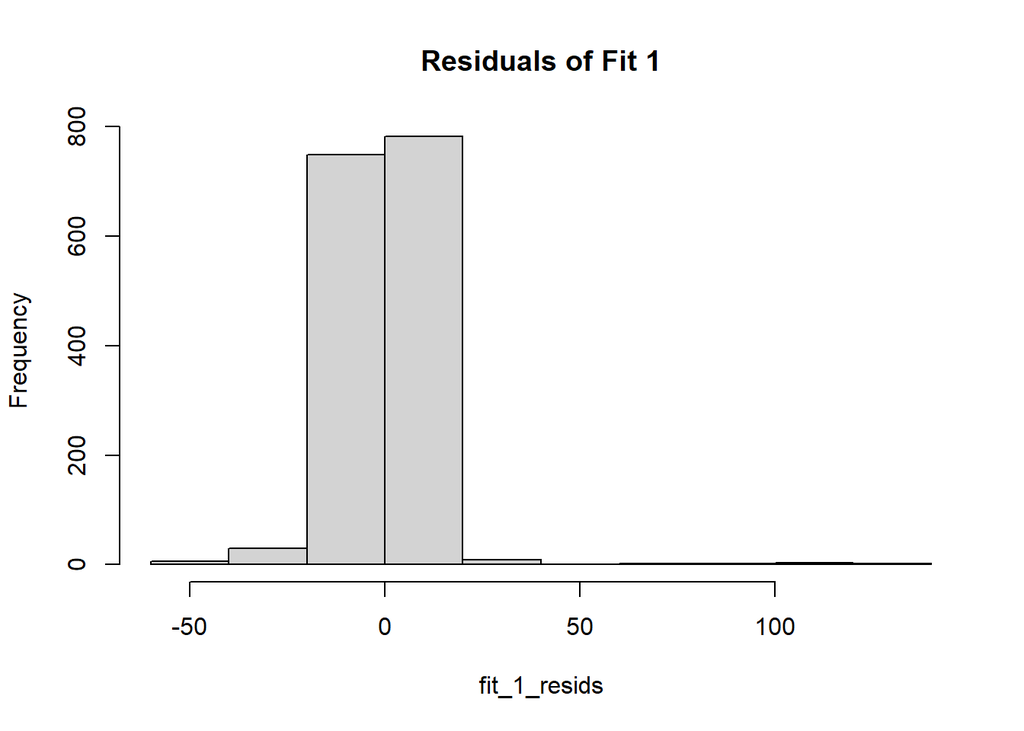

```
##
##  Shapiro-Wilk normality test
##
## data:  fit_1_resids
## W = 0.73462, p-value < 2.2e-16
```

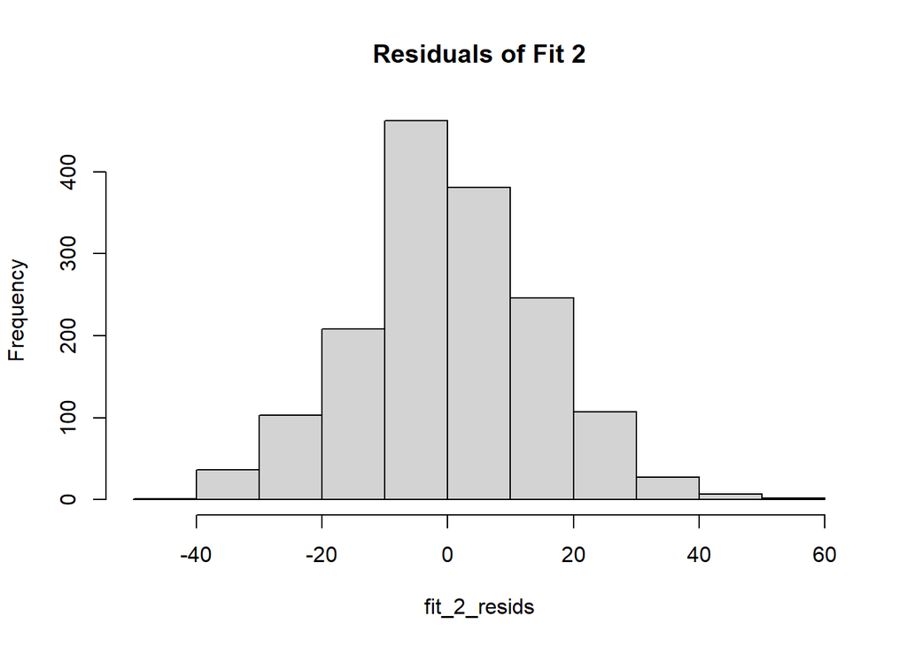

```
##
##  Shapiro-Wilk normality test
##
## data:  fit_2_resids
## W = 0.99563, p-value = 0.0001541
```

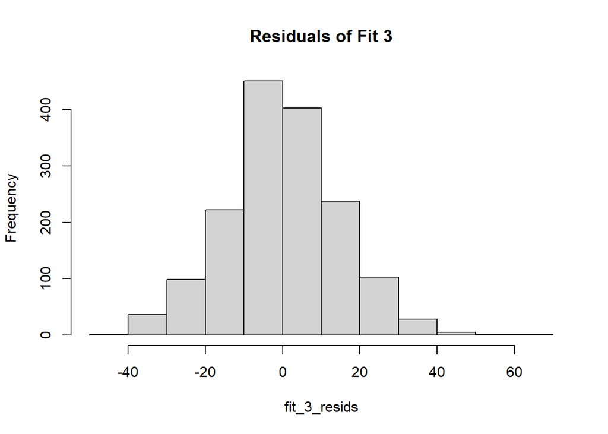

```
##
##  Shapiro-Wilk normality test
##
## data:  fit_3_resids
## W = 0.99535, p-value = 8.103e-05
```

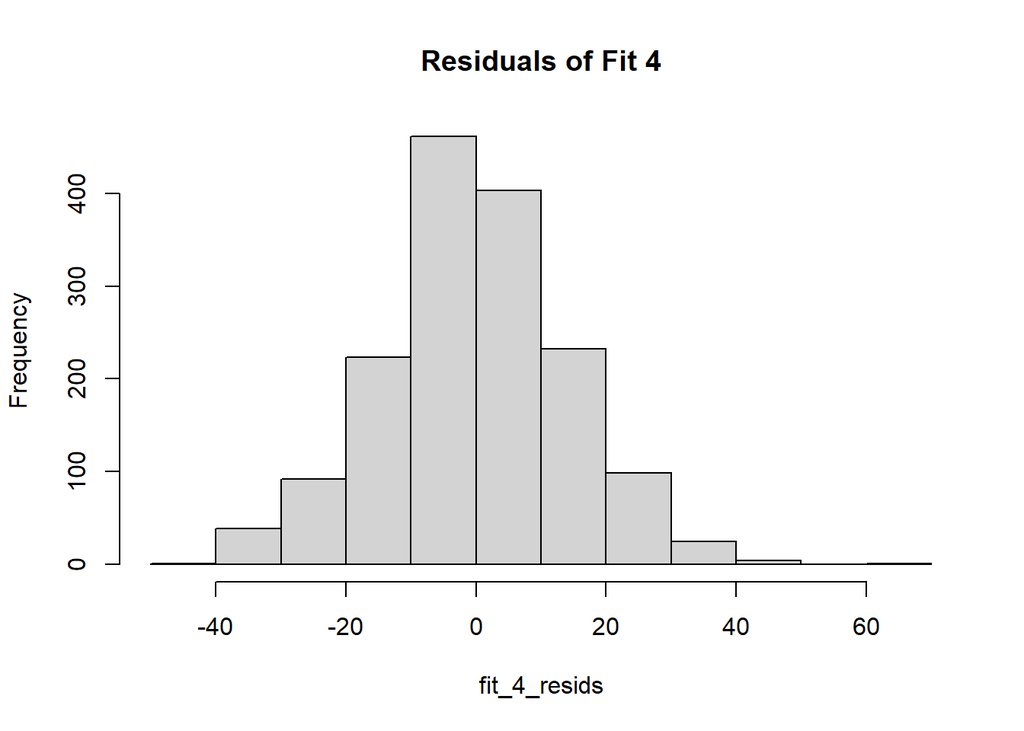

```
##
##  Shapiro-Wilk normality test
##
## data:  fit_4_resids
## W = 0.99525, p-value = 6.805e-05
```

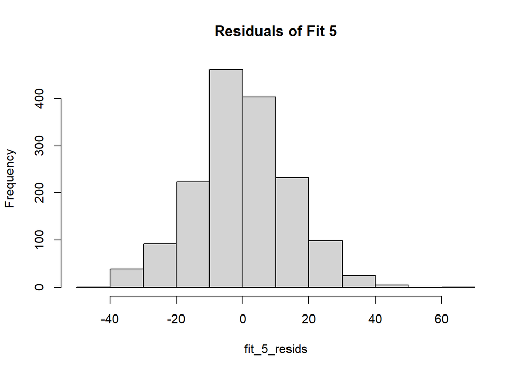

```
##
##  Shapiro-Wilk normality test
##
## data:  fit_5_resids
## W = 0.99526, p-value = 6.816e-05
```

Q5: What do you conclude about residual normality based on the numerical and graphical diagnostics?

**Based on the numerical and graphical diagnostics, I conclude that all five fit residuals fail the normality tests. While some of the histograms looked close to normal distribution, all the Shapiro test p values were significantly lower than 0.05 (reject the null that the data is normally distributed).**

Q6: Are violations of the normality assumption equally severe for all the models?

**The violations for the normality assumption were equally severe for models 2 through 5, however model 1 residuals are no where near being normally distributed, (p value < 2.2e-16 and histogram evidence).**

## Model Interpretation

**Simple Linear Regression**

|  | Estimate | Std. Error | t value | Pr(>\|t\|) |
| --- | --- | --- | --- | --- |
| (Intercept) | 76.1246565 | 0.9158120 | 83.12258 | 0 |
| body_mass | 0.8754988 | 0.0196905 | 44.46298 | 0 |

Q7: What is the magnitude of the mass/length relationship?

**The magnitude of the mass/length relationship is the slope of 0.875.**

Q9: What is the expected body length of an animal that weighs 0g?

**76.124**

**Body Mass: Coefficient Tables**

|  | Estimate | Std. Error | t value | Pr(>\|t\|) |
| --- | --- | --- | --- | --- |
| (Intercept) | 42.711465 | 0.5288929 | 80.756355 | 0.0000000 |
| sexmale | 2.784133 | 0.7456117 | 3.734024 | 0.0001951 |

|  | Estimate | Std. Error | t value | Pr(>\|t\|) |
| --- | --- | --- | --- | --- |
| (Intercept) | 46.752427 | 0.4499933 | 103.89582 | 0 |
| binomialDelomys sublineatus | -7.683058 | 0.7604562 | -10.10322 | 0 |

|  | Estimate | Std. Error | t value | Pr(>\|t\|) |
| --- | --- | --- | --- | --- |
| (Intercept) | 45.070355 | 0.5556429 | 81.113891 | 0e+00 |
| sexmale | 3.795395 | 0.7259609 | 5.228099 | 2e-07 |
| binomialDelomys sublineatus | -8.193492 | 0.7609985 | -10.766764 | 0e+00 |

|  | Estimate | Std. Error | t value | Pr(>\|t\|) |
| --- | --- | --- | --- | --- |
| (Intercept) | 45.0554562 | 0.6052973 | 74.4352459 | 0.0000000 |
| sexmale | 3.8280908 | 0.8966667 | 4.2692460 | 0.0000208 |
| binomialDelomys sublineatus | -8.1417394 | 1.1281046 | -7.2171847 | 0.0000000 |
| sexmale:binomialDelomys sublineatus | -0.0950187 | 1.5285856 | -0.0621612 | 0.9504424 |

Q10: What is the base level for sex?

**Female**

Q11: What is the base level for binomial?

**Delomys Dorsalis**

Q12: Which sex is heavier? How do you know?

**The males are heavier because the model coefficient is positive meaning there is an increase from the female body mass.**

Q13: Which species is heavier? How do you know?

**The Dorsalis species are heavier because the model coefficient for Sublineatus is negative meaning there is a decrease from the Dorsalis body mass.**

**ANOVA Tables**

|  | Df | Sum Sq | Mean Sq | F value | Pr(>F) |
| --- | --- | --- | --- | --- | --- |
| sex | 1 | 3061.678 | 3061.6779 | 13.94294 | 0.0001951 |
| Residuals | 1578 | 346507.131 | 219.5863 | NA | NA |

|  | Df | Sum Sq | Mean Sq | F value | Pr(>F) |
| --- | --- | --- | --- | --- | --- |
| binomial | 1 | 21289.68 | 21289.6805 | 102.0751 | 0 |
| Residuals | 1583 | 330164.45 | 208.5688 | NA | NA |

|  | Df | Sum Sq | Mean Sq | F value | Pr(>F) |
| --- | --- | --- | --- | --- | --- |
| sex | 1 | 3061.678 | 3061.6779 | 14.95838 | 0.0001144 |
| binomial | 1 | 23727.134 | 23727.1342 | 115.92320 | 0.0000000 |
| Residuals | 1577 | 322779.997 | 204.6798 | NA | NA |

|  | Df | Sum Sq | Mean Sq | F value | Pr(>F) |
| --- | --- | --- | --- | --- | --- |
| sex | 1 | 3.061678e+03 | 3.061678e+03 | 14.948932 | 0.0001150 |
| binomial | 1 | 2.372713e+04 | 2.372713e+04 | 115.849977 | 0.0000000 |
| sex:binomial | 1 | 7.913846e-01 | 7.913846e-01 | 0.003864 | 0.9504424 |
| Residuals | 1576 | 3.227792e+05 | 2.048091e+02 | NA | NA |

Q14: Are sex and species significant predictors for body mass?

**Yes, both sex and species are significant predictors for body mass.**

Q15: Is there a significant interaction?

**There is not a significant interaction (sex:binomial p value 0.950442).**

Q16: Examine the p-values for the main effects (sex and species) in all four of the ANOVA tables. Does the significance level of either main effect change very much among the different models?

**The significance levels of both main effects (sex and species) do not change very much among the different models.**

## Model Comparison: Body Mass

**choosing the best model for body mass can be done by identifying the lowest AIC value**

|  | df | AIC |
| --- | --- | --- |
| fit_2 | 3 | 13006.80 |
| fit_3 | 3 | 12966.36 |
| fit_4 | 4 | 12896.73 |
| fit_5 | 5 | 12898.72 |

Q17: Which two models have the lowest AIC?

**Fit_4 and fit_5 have the lowest AIC.**

Q18: Which of the two models with lowest AIC scores would you select? Explain your decision based on model fit and the complexity/understanding tradeoff.

**I would select the fit_4 model because it not only has the lower of the two AIC scores, it also had a slightly more significant Pr(>F) value of sex (0.0001144<0.0001150). The interaction between the two predictor values of fit 5 also did not show significance. Lastly, when taking into consideration the complexity/understanding tradeoff, I believe that using an additive model will be easier to comprehend than the interactive.**